# Reproducible Research: Peer Assessment 1

## Assumptions

- Current working directory is set to current project
- File name is *activity.csv* and is present in the current working directory

## Libraries used

```r
library(dplyr)
library(ggplot2)
library(lubridate)
```

## Loading and preprocessing the data

> Show any code that is needed to

> Load the data (i.e. read.csv()) Process/transform the data (if necessary) into a format suitable for your analysis

```r
activity <- read.csv(file = "activity.csv", header = TRUE, colClasses = c("numeric", "character", "integer"))

# Convert the date to correct format
activity$date <- ymd(activity$date)

# quickly check the data
names(activity)
```

```
## [1] "steps"    "date"     "interval"
```

```r
str(activity)
```

```
## 'data.frame':    17568 obs. of  3 variables:
##  $ steps   : num  NA NA NA NA NA NA NA NA NA NA ...
##  $ date    : POSIXct, format: "2012-10-01" "2012-10-01" ...
##  $ interval: int  0 5 10 15 20 25 30 35 40 45 ...
```

```r
head(activity)
```

```
##   steps       date interval
## 1    NA 2012-10-01        0
## 2    NA 2012-10-01        5
## 3    NA 2012-10-01       10
## 4    NA 2012-10-01       15
## 5    NA 2012-10-01       20
## 6    NA 2012-10-01       25
```

```r
# subset data frame to values without na for later use
activity_nona <- activity[complete.cases(activity),]
```

## What is mean total number of steps taken per day?

> For this part of the assignment, you can ignore the missing values in the dataset.

> Calculate the total number of steps taken per day

> If you do not understand the difference between a histogram and a barplot, research the difference between them. Make a histogram of the total number of steps taken each day

> Calculate and report the mean and median of the total number of steps taken per day

```r
# Calculate the total number of steps taken per day
steps_per_day <- aggregate(steps ~ date, activity_nona, sum)

head(steps_per_day)
```

```
##         date steps
## 1 2012-10-02   126
## 2 2012-10-03 11352
## 3 2012-10-04 12116
## 4 2012-10-05 13294
## 5 2012-10-06 15420
## 6 2012-10-07 11015
```

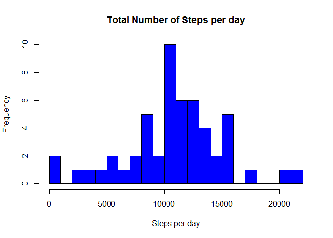

```r
# draw the histogram
hist(steps_per_day$steps, col = "blue", xlab = "Steps per day", main = "Total Number of Steps per day", breaks = 20)
```

```r
# Calculate and report the mean and median of the total number of steps taken per day

# mean
mean(steps_per_day$steps)
```

```
## [1] 10766.19
```

```r
# median
median(steps_per_day$steps)
```

```
## [1] 10765
```

## What is the average daily activity pattern?

> What is the average daily activity pattern?

> Make a time series plot (i.e. type = “l”) of the 5-minute interval (x-axis) and the average number of steps taken, averaged across all days (y-axis)

> Which 5-minute interval, on average across all the days in the dataset, contains the maximum number of steps?

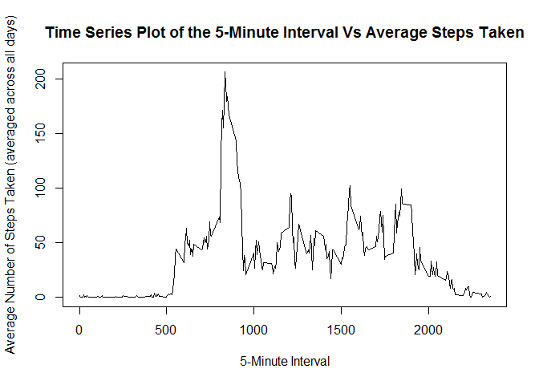

```r
interval_data <- aggregate(steps ~ interval, activity_nona, mean)
names(interval_data)[2] <- "mean_steps"

# Make a time series plot (i.e. type = "l") of the 5-minute interval (x-axis) and the average number of steps taken, averaged across all days (y-axis)
plot(
  x = interval_data$interval,
  y = interval_data$mean_steps,
  type = "l",
  main = "Time Series Plot of the 5-Minute Interval Vs Average Steps Taken",
  xlab = "5-Minute Interval",
  ylab = "Average Number of Steps Taken (averaged across all days)"
)
```

```r
# Which 5-minute interval, on average across all the days in the dataset, contains the maximum number of steps?
interval_data[interval_data$mean_steps==max(interval_data$mean_steps),]
```

```
##     interval mean_steps
## 104      835   206.1698
```

## Imputing missing values

> Note that there are a number of days/intervals where there are missing values (coded as NA). The presence of missing days may introduce bias into some calculations or summaries of the data.

> Calculate and report the total number of missing values in the dataset (i.e. the total number of rows with NAs)

```r
# Calculate and report the total number of missing values in the dataset (i.e. the total number of rows with NAs)
missingdata <- is.na(activity$steps)
sum(missingdata)
```

```
## [1] 2304
```

> Devise a strategy for filling in all of the missing values in the dataset. The strategy does not need to be sophisticated. For example, you could use the mean/median for that day, or the mean for that 5-minute interval, etc.

> Create a new dataset that is equal to the original dataset but with the missing data filled in.

Strategy to fill the missing value is to put the mean of all non-NA values of that interval (across all days)

```r
filled_data <- activity
avg_interval <- tapply(filled_data$steps, filled_data$interval, mean, na.rm=TRUE, simplify=TRUE)
filled_data$steps[missingdata] <- avg_interval[as.character(filled_data$interval[missingdata])]

# Check if all NA are filled
sum(is.na(filled_data))
```

```
## [1] 0
```

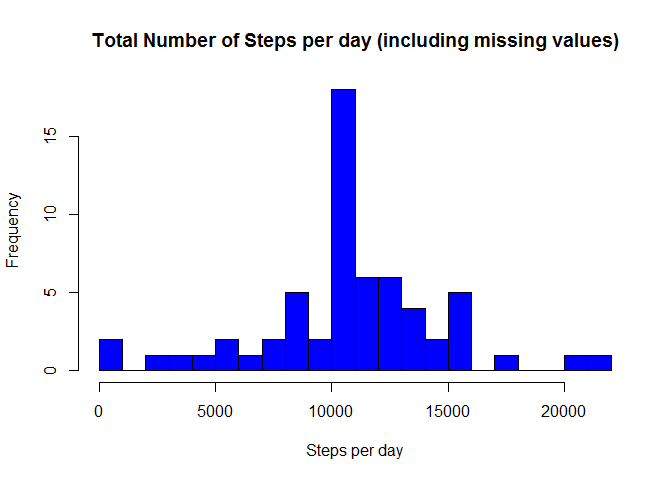

```r
# steps per day, including missing values
steps_per_day_nona <- aggregate(steps ~ date, filled_data, sum)
hist(steps_per_day_nona$steps, col = "blue", xlab = "Steps per day", main = "Total Number of Steps per day (including missing values)", breaks=20)
```

## Are there differences in activity patterns between weekdays and weekends?

> For this part the weekdays() function may be of some help here. Use the dataset with the filled-in missing values for this part.

> Create a new factor variable in the dataset with two levels – “weekday” and “weekend” indicating whether a given date is a weekday or weekend day.

```r
filled_data <- mutate(filled_data, weektype = ifelse(weekdays(filled_data$date) == "Saturday" | weekdays(filled_data$date) == "Sunday", "weekend", "weekday"))
```

> Make a panel plot containing a time series plot (i.e. type = “l”) of the 5-minute interval (x-axis) and the average number of steps taken, averaged across all weekday days or weekend days (y-axis). See the README file in the GitHub repository to see an example of what this plot should look like using simulated data.

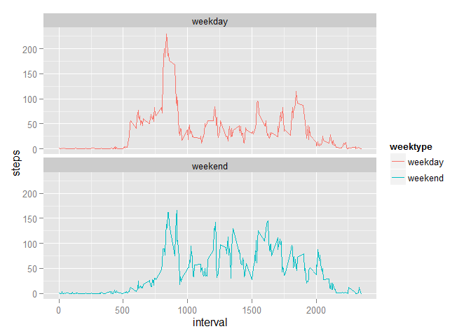

```r
steps_per_day_weektype <- aggregate(steps ~ interval + weektype, filled_data, mean)

s <- ggplot(steps_per_day_weektype, aes(x=interval, y=steps, color = weektype)) +
  geom_line() +  facet_wrap(~weektype, ncol = 1, nrow=2)

print(s)
```

From the two plots it seems that there is more activity earlier in the day during weekdays compared to weekends, but more activity throughout the weekends compared with weekdays